> This is the Notebook for the Lifesure Project in Explainability AI made by the group 9 composed by :

> > CUCHE Claire, DARDE Inès, DE WILDE Chloé, GINDRE Louis

# LifeSure Project

As Lifesure aims to integrate sustainability into its business model, this notebook reflects our analysis of the US market. The objective of this notebook is to provide a structured approach to collect and preprocess external data to analyze the different behaviors and preferences.

In addition, we provided a dashboard used to visualize this data and help executive to take some adviced decisions.

```python
from google.colab import files
import pandas as pd
import requests
import numpy as np
import seaborn as sns
import matplotlib.pyplot as plt
from scipy.stats import chi2_contingency
from sklearn.cluster import KMeans
from sklearn.preprocessing import StandardScaler
```

# Phase 1 : Data Collection and Integration

## Data Collection

We chose the folllowing datasets to gather and integrate relevant external data sources for a comprehensive understanding of customer behaviors and market trends : Medical costs, compared to air quality

```python
'''
medical cost:
https://www.kaggle.com/datasets/mirichoi0218/insurance

air quality:
https://www.kaggle.com/datasets/yakhyojon/air-quality-data
'''
```

```
'\nmedical cost:\nhttps://www.kaggle.com/datasets/mirichoi0218/insurance\n\nair quality:\nhttps://www.kaggle.com/datasets/yakhyojon/air-quality-data\n'
```

```python
uploaded = files.upload()
```

Upload widget is only available when the cell has been executed in the current browser session. Please rerun this cell to enable.

```
Saving c4_epa_air_quality.csv to c4_epa_air_quality.csv
```

These datasets can be useful in fulfilling LifeSure Insurance's strategic objectives. The information provided by these datasets can be used to analyze market trends, environmental factors, societal expectations, etc.

First, we have a dataset based on the medical costs billed to each person, depending on their age, BMI, region, etc. This dataset will allow us to better understand customers and their insurance needs. Certain data are essential in this regard:

```python
df_cost = pd.read_csv('insurance.csv', sep=',', encoding='latin-1')
df_cost = pd.DataFrame(df_cost)
df_cost.head()
```

|  | age | sex | bmi | children | smoker | region | charges |
| --- | --- | --- | --- | --- | --- | --- | --- |
| 0 | 19 | female | 27.900 | 0 | yes | southwest | 16884.92400 |
| 1 | 18 | male | 33.770 | 1 | no | southeast | 1725.55230 |
| 2 | 28 | male | 33.000 | 3 | no | southeast | 4449.46200 |
| 3 | 33 | male | 22.705 | 0 | no | northwest | 21984.47061 |
| 4 | 32 | male | 28.880 | 0 | no | northwest | 3866.85520 |

- Age allows us to identify which population segments generate the highest insurance costs: this could be used to tailor offers based on risk profiles (for example, we could consider different offers for seniors and young workers).
- Gender is a key dimension in understanding these differences. BMI can also provide us with key insights, particularly regarding its link to chronic diseases. Smoking is also a major risk factor, and therefore worth considering in these insurance policies. An indicator of the number of children allows us to take a broader approach, as does the region, which can help us analyze geographic disparities and consider them in new insurance policies that meet individual needs.

Although insurance policies must evolve toward more modern ones that better meet consumer expectations, it is essential to consider the medical costs billed based on these criteria to enable us to link these variables and adjust insurance policies.

This first dataset therefore aims to better understand the clientele, particularly to identify risk profiles and adapt offers to make them more attractive, without compromising LifeSure's business model.

```python
df_air = pd.read_csv('c4_epa_air_quality.csv', sep=',', encoding='latin-1')
df_air = pd.DataFrame(df_air)
df_air.head()
```

|  | Unnamed: 0 | date_local | state_name | county_name | city_name | local_site_name | parameter_name | units_of_measure | arithmetic_mean | aqi |
| --- | --- | --- | --- | --- | --- | --- | --- | --- | --- | --- |
| 0 | 0 | 2018-01-01 | Arizona | Maricopa | Buckeye | BUCKEYE | Carbon monoxide | Parts per million | 0.473684 | 7 |
| 1 | 1 | 2018-01-01 | Ohio | Belmont | Shadyside | Shadyside | Carbon monoxide | Parts per million | 0.263158 | 5 |
| 2 | 2 | 2018-01-01 | Wyoming | Teton | Not in a city | Yellowstone National Park - Old Faithful Snow ... | Carbon monoxide | Parts per million | 0.111111 | 2 |
| 3 | 3 | 2018-01-01 | Pennsylvania | Philadelphia | Philadelphia | North East Waste (NEW) | Carbon monoxide | Parts per million | 0.300000 | 3 |
| 4 | 4 | 2018-01-01 | Iowa | Polk | Des Moines | CARPENTER | Carbon monoxide | Parts per million | 0.215789 | 3 |

The second dataset allows us to clearly identify a link between the environment and health, as this debate is increasingly central to society. It is therefore important to consider it in new insurance policies, as this environmental dimension is relatively new to analyses.

The dataset provides us with indicators on air quality, particularly pollutants that have an impact on individual health. Geographic data allows us to cross-reference the two datasets, integrating new variables to measure the importance of this new dimension in insurance policy choices. Cross-referencing this data will allow us to anticipate risks and adjust insurance policies based on this criterion.

It is strategic to move from the current insurance model, which is reactive (i.e., insurance policies are similar for everyone) to a predictive model, which better understands risk factors by integrating these preventive criteria into society. Sustainability and social responsibility factors are also interesting for aligning LifeSum's positions with environmental issues. In this model, LifeSum not only covers costs but can also play an active role in prevention. This allows us to develop a comprehensive view of the insurance market, integrating social, demographic, and environmental factors, and thus enable strategic decision-making.

## Data Preparation and Cleaning

Now that we have our datasets, let's try and clean it to be able to process it and provide LifeSure with visualizations. To do this, we will address abnormal data and standardize our dataset for easy integration. For some variables, we will encode them to create new ones, for example to categorize people according to their BMI.

At the end, we will merge our 2 datasets to create a unified one, that we will use in our visualization tools.

```python
df_cost.info()
```

```
<class 'pandas.core.frame.DataFrame'>
RangeIndex: 1338 entries, 0 to 1337
Data columns (total 7 columns):
 #   Column    Non-Null Count  Dtype
---  ------    --------------  -----
 0   age       1338 non-null   int64
 1   sex       1338 non-null   object
 2   bmi       1338 non-null   float64
 3   children  1338 non-null   int64
 4   smoker    1338 non-null   object
 5   region    1338 non-null   object
 6   charges   1338 non-null   float64
dtypes: float64(2), int64(2), object(3)
memory usage: 73.3+ KB
```

```python
df_air.info()
```

```
<class 'pandas.core.frame.DataFrame'>
RangeIndex: 260 entries, 0 to 259
Data columns (total 10 columns):
 #   Column            Non-Null Count  Dtype
---  ------            --------------  -----
 0   Unnamed: 0        260 non-null    int64
 1   date_local        260 non-null    object
 2   state_name        260 non-null    object
 3   county_name       260 non-null    object
 4   city_name         260 non-null    object
 5   local_site_name   257 non-null    object
 6   parameter_name    260 non-null    object
 7   units_of_measure  260 non-null    object
 8   arithmetic_mean   260 non-null    float64
 9   aqi               260 non-null    int64
dtypes: float64(1), int64(2), object(7)
memory usage: 20.4+ KB
```

```python
df_cost.isnull().sum()
```

|  | 0 |
| --- | --- |
| age | 0 |
| sex | 0 |
| bmi | 0 |
| children | 0 |
| smoker | 0 |
| region | 0 |
| charges | 0 |

**dtype:** int64

```python
df_air.isnull().sum()
```

|  | 0 |
| --- | --- |
| Unnamed: 0 | 0 |
| date_local | 0 |
| state_name | 0 |
| county_name | 0 |
| city_name | 0 |
| local_site_name | 3 |
| parameter_name | 0 |
| units_of_measure | 0 |
| arithmetic_mean | 0 |
| aqi | 0 |

**dtype:** int64

```python
df_cost.describe()
```

|  | age | bmi | children | charges |
| --- | --- | --- | --- | --- |
| count | 1338.000000 | 1338.000000 | 1338.000000 | 1338.000000 |
| mean | 39.207025 | 30.663397 | 1.094918 | 13270.422265 |
| std | 14.049960 | 6.098187 | 1.205493 | 12110.011237 |
| min | 18.000000 | 15.960000 | 0.000000 | 1121.873900 |
| 25% | 27.000000 | 26.296250 | 0.000000 | 4740.287150 |
| 50% | 39.000000 | 30.400000 | 1.000000 | 9382.033000 |
| 75% | 51.000000 | 34.693750 | 2.000000 | 16639.912515 |
| max | 64.000000 | 53.130000 | 5.000000 | 63770.428010 |

We can see that we have 3 columns for numerical values, if we remove `children`one, as we see that we obviously don't have any outliers.

Let's use the IQR method to remove the outliers.

```python
def remove_outliers(df, column):
    Q1 = df[column].quantile(0.25)
    Q3 = df[column].quantile(0.75)
    IQR = Q3 - Q1
    lower_bound = Q1 - 1.5 * IQR
    upper_bound = Q3 + 1.5 * IQR
    df = df[(df[column] >= lower_bound) & (df[column] <= upper_bound)]
    return df

num_cols = ['age', 'bmi', 'charges']
for col in num_cols:
    df_cost = remove_outliers(df_cost, col)
```

```python
df_cost.info()
```

```
<class 'pandas.core.frame.DataFrame'>
Index: 1191 entries, 0 to 1337
Data columns (total 7 columns):
 #   Column    Non-Null Count  Dtype
---  ------    --------------  -----
 0   age       1191 non-null   int64
 1   sex       1191 non-null   object
 2   bmi       1191 non-null   float64
 3   children  1191 non-null   int64
 4   smoker    1191 non-null   object
 5   region    1191 non-null   object
 6   charges   1191 non-null   float64
dtypes: float64(2), int64(2), object(3)
memory usage: 74.4+ KB
```

```python
df_air.describe()
```

|  | Unnamed: 0 | arithmetic_mean | aqi |
| --- | --- | --- | --- |
| count | 260.000000 | 260.000000 | 260.000000 |
| mean | 129.500000 | 0.403169 | 6.757692 |
| std | 75.199734 | 0.317902 | 7.061707 |
| min | 0.000000 | 0.000000 | 0.000000 |
| 25% | 64.750000 | 0.200000 | 2.000000 |
| 50% | 129.500000 | 0.276315 | 5.000000 |
| 75% | 194.250000 | 0.516009 | 9.000000 |
| max | 259.000000 | 1.921053 | 50.000000 |

We see that the column unnamed is not interesting for us, as this is not meaningful at all. For the other columns, let's compute the remove outliers function.

```python
df_air.head()
```

|  | Unnamed: 0 | date_local | state_name | county_name | city_name | local_site_name | parameter_name | units_of_measure | arithmetic_mean | aqi |
| --- | --- | --- | --- | --- | --- | --- | --- | --- | --- | --- |
| 0 | 0 | 2018-01-01 | Arizona | Maricopa | Buckeye | BUCKEYE | Carbon monoxide | Parts per million | 0.473684 | 7 |
| 1 | 1 | 2018-01-01 | Ohio | Belmont | Shadyside | Shadyside | Carbon monoxide | Parts per million | 0.263158 | 5 |
| 2 | 2 | 2018-01-01 | Wyoming | Teton | Not in a city | Yellowstone National Park - Old Faithful Snow ... | Carbon monoxide | Parts per million | 0.111111 | 2 |
| 3 | 3 | 2018-01-01 | Pennsylvania | Philadelphia | Philadelphia | North East Waste (NEW) | Carbon monoxide | Parts per million | 0.300000 | 3 |
| 4 | 4 | 2018-01-01 | Iowa | Polk | Des Moines | CARPENTER | Carbon monoxide | Parts per million | 0.215789 | 3 |

We can see that this column is only for indexing purposes, so let's remove it.

```python
num_cols = ['arithmetic_mean', 'aqi']  # Adjust as necessary
for col in num_cols:
    df_air = remove_outliers(df_air, col)
```

```python
df_air.drop(columns=['Unnamed: 0'], inplace=True)
```

```python
df_air.info()
```

```
<class 'pandas.core.frame.DataFrame'>
Index: 229 entries, 0 to 259
Data columns (total 9 columns):
 #   Column            Non-Null Count  Dtype
---  ------            --------------  -----
 0   date_local        229 non-null    object
 1   state_name        229 non-null    object
 2   county_name       229 non-null    object
 3   city_name         229 non-null    object
 4   local_site_name   226 non-null    object
 5   parameter_name    229 non-null    object
 6   units_of_measure  229 non-null    object
 7   arithmetic_mean   229 non-null    float64
 8   aqi               229 non-null    int64
dtypes: float64(1), int64(1), object(7)
memory usage: 17.9+ KB
```

Now that we handled abnormal values, let's do some standardization and formatting so that our visualization will be meaningfull and easy to interpret, as it will be in the same scale for all categories.

We will first convert our variables into categories and compute some bins so we can group people according to their physical characteristics.

```python
df_cost['sex'] = df_cost['sex'].astype('category')
df_cost['smoker'] = df_cost['smoker'].map({'yes': True, 'no': False})
df_cost['region'] = df_cost['region'].astype('category')
```

```python
bins_age = [18, 25, 35, 45, 55, 65, 100]
labels_age = ['18-25', '26-35', '36-45', '46-55', '56-65', '65+']
df_cost['age_group'] = pd.cut(df_cost['age'], bins=bins_age, labels=labels_age, right=False)
```

```python
bins_bmi = [0, 18.5, 24.9, 29.9, 35, 100]
labels_bmi = ['Underweight', 'Normal', 'Overweight', 'Obese', 'Extremely Obese']
df_cost['bmi_category'] = pd.cut(df_cost['bmi'], bins=bins_bmi, labels=labels_bmi, right=False)
```

```python
df_air['date_local'] = pd.to_datetime(df_air['date_local'])
df_air['year'] = df_air['date_local'].dt.year
df_air['month'] = df_air['date_local'].dt.month
df_air['day'] = df_air['date_local'].dt.day
```

```python
df_air.head()
```

|  | date_local | state_name | county_name | city_name | local_site_name | parameter_name | units_of_measure | arithmetic_mean | aqi | year | month | day |
| --- | --- | --- | --- | --- | --- | --- | --- | --- | --- | --- | --- | --- |
| 0 | 2018-01-01 | Arizona | Maricopa | Buckeye | BUCKEYE | Carbon monoxide | Parts per million | 0.473684 | 7 | 2018 | 1 | 1 |
| 1 | 2018-01-01 | Ohio | Belmont | Shadyside | Shadyside | Carbon monoxide | Parts per million | 0.263158 | 5 | 2018 | 1 | 1 |
| 2 | 2018-01-01 | Wyoming | Teton | Not in a city | Yellowstone National Park - Old Faithful Snow ... | Carbon monoxide | Parts per million | 0.111111 | 2 | 2018 | 1 | 1 |
| 3 | 2018-01-01 | Pennsylvania | Philadelphia | Philadelphia | North East Waste (NEW) | Carbon monoxide | Parts per million | 0.300000 | 3 | 2018 | 1 | 1 |
| 4 | 2018-01-01 | Iowa | Polk | Des Moines | CARPENTER | Carbon monoxide | Parts per million | 0.215789 | 3 | 2018 | 1 | 1 |

Our work here consisted in converting date and encoding the categorical values. We did some feature engineering too in order to create new insights in our dataset.

Now that our datasets are clean, it's time to merge them to create one usable dataset in our report. We will map the data so we can map the region to the state, as the 2 columns are not the same. We need to standardize the column format.

```python
region_to_state = {
    "northeast": [
        "Maine", "New Hampshire", "Vermont", "Massachusetts", "Rhode Island", "Connecticut",
        "New York", "New Jersey", "Pennsylvania"
    ],
    "southeast": [
        "Delaware", "Maryland", "West Virginia", "Virginia", "Kentucky", "Tennessee",
        "North Carolina", "South Carolina", "Georgia", "Florida", "Alabama",
        "Mississippi", "Arkansas", "Louisiana", "District Of Columbia", "Puerto Rico"
    ],
    "southwest": [
        "Texas", "Oklahoma", "New Mexico", "Arizona", "Nevada", "Utah", "California", "Colorado"
    ],
    "northwest": [
        "Washington", "Oregon", "Idaho", "Montana", "Wyoming", "North Dakota", "South Dakota",
        "Nebraska", "Kansas", "Missouri", "Iowa", "Minnesota", "Wisconsin", "Illinois",
        "Indiana", "Ohio", "Michigan", "Alaska", "Hawaii"
    ]
}

def assign_region(state):
    for region, states in region_to_state.items():
        if state in states:
            return region
    return None

df_air["region"] = df_air["state_name"].apply(assign_region)
```

```python
df_air.head()
```

|  | date_local | state_name | county_name | city_name | local_site_name | parameter_name | units_of_measure | arithmetic_mean | aqi | year | month | day | region |
| --- | --- | --- | --- | --- | --- | --- | --- | --- | --- | --- | --- | --- | --- |
| 0 | 2018-01-01 | Arizona | Maricopa | Buckeye | BUCKEYE | Carbon monoxide | Parts per million | 0.473684 | 7 | 2018 | 1 | 1 | southwest |
| 1 | 2018-01-01 | Ohio | Belmont | Shadyside | Shadyside | Carbon monoxide | Parts per million | 0.263158 | 5 | 2018 | 1 | 1 | northwest |
| 2 | 2018-01-01 | Wyoming | Teton | Not in a city | Yellowstone National Park - Old Faithful Snow ... | Carbon monoxide | Parts per million | 0.111111 | 2 | 2018 | 1 | 1 | northwest |
| 3 | 2018-01-01 | Pennsylvania | Philadelphia | Philadelphia | North East Waste (NEW) | Carbon monoxide | Parts per million | 0.300000 | 3 | 2018 | 1 | 1 | northeast |
| 4 | 2018-01-01 | Iowa | Polk | Des Moines | CARPENTER | Carbon monoxide | Parts per million | 0.215789 | 3 | 2018 | 1 | 1 | northwest |

```python
df_cost.head()
```

|  | age | sex | bmi | children | smoker | region | charges | age_group | bmi_category |
| --- | --- | --- | --- | --- | --- | --- | --- | --- | --- |
| 0 | 19 | female | 27.900 | 0 | True | southwest | 16884.92400 | 18-25 | Overweight |
| 1 | 18 | male | 33.770 | 1 | False | southeast | 1725.55230 | 18-25 | Obese |
| 2 | 28 | male | 33.000 | 3 | False | southeast | 4449.46200 | 26-35 | Obese |
| 3 | 33 | male | 22.705 | 0 | False | northwest | 21984.47061 | 26-35 | Normal |
| 4 | 32 | male | 28.880 | 0 | False | northwest | 3866.85520 | 26-35 | Overweight |

Now, we have region in both datasets and we can process to merge.

```python
df_merged = pd.merge(df_cost, df_air, on="region", how="inner")
df_merged.head()
```

|  | age | sex | bmi | children | smoker | region | charges | age_group | bmi_category | date_local | ... | county_name | city_name | local_site_name | parameter_name | units_of_measure | arithmetic_mean | aqi | year | month | day |
| --- | --- | --- | --- | --- | --- | --- | --- | --- | --- | --- | --- | --- | --- | --- | --- | --- | --- | --- | --- | --- | --- |
| 0 | 19 | female | 27.9 | 0 | True | southwest | 16884.924 | 18-25 | Overweight | 2018-01-01 | ... | Maricopa | Buckeye | BUCKEYE | Carbon monoxide | Parts per million | 0.473684 | 7 | 2018 | 1 | 1 |
| 1 | 19 | female | 27.9 | 0 | True | southwest | 16884.924 | 18-25 | Overweight | 2018-01-01 | ... | Larimer | Fort Collins | Fort Collins - CSU - S. Mason | Carbon monoxide | Parts per million | 0.300000 | 6 | 2018 | 1 | 1 |
| 2 | 19 | female | 27.9 | 0 | True | southwest | 16884.924 | 18-25 | Overweight | 2018-01-01 | ... | Maricopa | Mesa | MESA | Carbon monoxide | Parts per million | 0.505263 | 10 | 2018 | 1 | 1 |
| 3 | 19 | female | 27.9 | 0 | True | southwest | 16884.924 | 18-25 | Overweight | 2018-01-01 | ... | San Bernardino | Ontario | Ontario Near Road (Etiwanda) | Carbon monoxide | Parts per million | 0.747368 | 11 | 2018 | 1 | 1 |
| 4 | 19 | female | 27.9 | 0 | True | southwest | 16884.924 | 18-25 | Overweight | 2018-01-01 | ... | Washoe | Reno | Reno3 | Carbon monoxide | Parts per million | 0.400000 | 7 | 2018 | 1 | 1 |

5 rows × 21 columns

```python
df_merged.columns
```

```
Index(['age', 'sex', 'bmi', 'children', 'smoker', 'region', 'charges',
       'age_group', 'bmi_category', 'date_local', 'state_name', 'county_name',
       'city_name', 'local_site_name', 'parameter_name', 'units_of_measure',
       'arithmetic_mean', 'aqi', 'year', 'month', 'day'],
      dtype='object')
```

We have this dataset that could be exported to a csv file, in order to be processed in the graphical representations. Here, we sent directly the datasets in csv format in order to be processed easily.

This dataset is useful but we still have loads of categorical values, that might not fit into our visualization tools. Let's create a more complete df with dummies to process these categories.

```python
df_merged1 = df_merged.copy()
```

```python
df_merged1 = pd.get_dummies(df_merged1, columns=['region'], prefix='region')
df_merged1 = pd.get_dummies(df_merged1, columns=['age_group'], prefix='age_group')
df_merged1 = pd.get_dummies(df_merged1, columns=['bmi_category'], prefix='bmi_category')
```

We can create some feature interactions too. This might be useful to understnad key insights and relations between values. We want to analyse the interactions that we think are the most important, to confirm or infirm our analysis.

```python
df_merged1['bmi_aqi'] = df_merged1['bmi'] * df_merged1['aqi']
df_merged1['smoker_aqi'] = df_merged1['smoker'] * df_merged1['aqi']
df_merged1['bmi_smoker_aqi'] = df_merged1['bmi'] * df_merged1['smoker'] * df_merged1['aqi']
```

AQI is very interesting for us, as this is the indicator for pollution. But its meaning might be a little bit difficult to understand, as this is not a common indicator known by anyone. Let's create some indications to analyse the AQI

```python
def categorize_aqi(aqi):
    if aqi <= 50:
        return 'Good'
    elif aqi <= 100:
        return 'Moderate'
    elif aqi <= 150:
        return 'Unhealthy for Sensitive Groups'
    elif aqi <= 200:
        return 'Unhealthy'
    elif aqi <= 300:
        return 'Very Unhealthy'
    else:
        return 'Hazardous'

df_merged1['aqi_category'] = df_merged1['aqi'].apply(categorize_aqi)
```

```python
df_merged1.head()
```

|  | age | sex | bmi | children | smoker | charges | date_local | state_name | county_name | city_name | ... | age_group_65+ | bmi_category_Underweight | bmi_category_Normal | bmi_category_Overweight | bmi_category_Obese | bmi_category_Extremely Obese | bmi_aqi | smoker_aqi | bmi_smoker_aqi | aqi_category |
| --- | --- | --- | --- | --- | --- | --- | --- | --- | --- | --- | --- | --- | --- | --- | --- | --- | --- | --- | --- | --- | --- |
| 0 | 19 | female | 27.9 | 0 | True | 16884.924 | 2018-01-01 | Arizona | Maricopa | Buckeye | ... | False | False | False | True | False | False | 195.3 | 7 | 195.3 | Good |
| 1 | 19 | female | 27.9 | 0 | True | 16884.924 | 2018-01-01 | Colorado | Larimer | Fort Collins | ... | False | False | False | True | False | False | 167.4 | 6 | 167.4 | Good |
| 2 | 19 | female | 27.9 | 0 | True | 16884.924 | 2018-01-01 | Arizona | Maricopa | Mesa | ... | False | False | False | True | False | False | 279.0 | 10 | 279.0 | Good |
| 3 | 19 | female | 27.9 | 0 | True | 16884.924 | 2018-01-01 | California | San Bernardino | Ontario | ... | False | False | False | True | False | False | 306.9 | 11 | 306.9 | Good |
| 4 | 19 | female | 27.9 | 0 | True | 16884.924 | 2018-01-01 | Nevada | Washoe | Reno | ... | False | False | False | True | False | False | 195.3 | 7 | 195.3 | Good |

5 rows × 37 columns

```python
df_merged1.columns
```

```
Index(['age', 'sex', 'bmi', 'children', 'smoker', 'charges', 'date_local',
       'state_name', 'county_name', 'city_name', 'local_site_name',
       'parameter_name', 'units_of_measure', 'arithmetic_mean', 'aqi', 'year',
       'month', 'day', 'region_northeast', 'region_northwest',
       'region_southeast', 'region_southwest', 'age_group_18-25',
       'age_group_26-35', 'age_group_36-45', 'age_group_46-55',
       'age_group_56-65', 'age_group_65+', 'bmi_category_Underweight',
       'bmi_category_Normal', 'bmi_category_Overweight', 'bmi_category_Obese',
       'bmi_category_Extremely Obese', 'bmi_aqi', 'smoker_aqi',
       'bmi_smoker_aqi', 'aqi_category'],
      dtype='object')
```

We can go to our next step to visualize our data

# Phase 2 : Data Analysis and Specifications

We should now take into consideration this dataset to understand the trends and correlations between our variables, this will lead to understand better the customers behavior.

LifeSure will then have access to a dashboard in order to make decision based on data about the current trends.

## Exploratory Data Analysis (EDA)

EDA will help us understand these trends, patterns and customer behaviors. These factors are essential since they will influence the policy selection for LifeSure. For example, we might discover the impact of environmental factors on the health of users. Histograms, scatter plots and time series could be used in this part.

Before going further, we can check the distribution of key numerical variables.

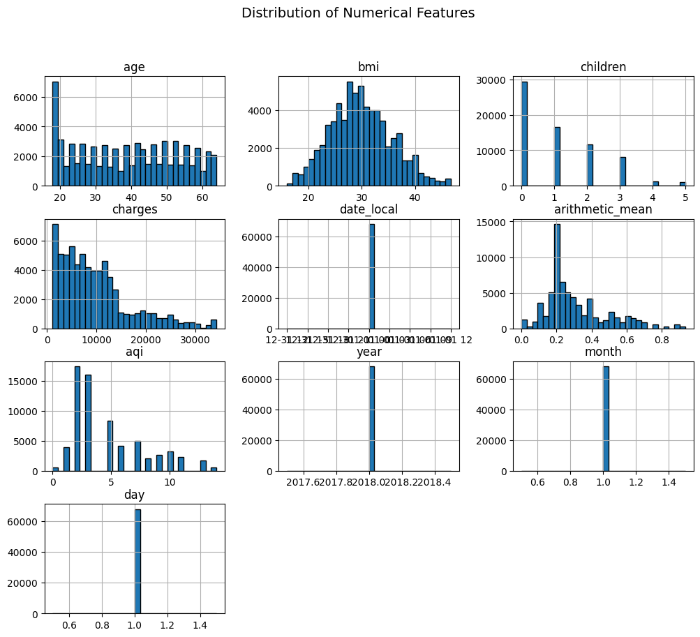

```python
df_merged.hist(figsize=(12, 10), bins=30, edgecolor='black')
plt.suptitle("Distribution of Numerical Features", fontsize=14)
plt.show()
```

Moreover, a small portion of customers have high medical costs, it will be interesting to see who they are and if they have common characteristics. The high medical charges for some customers may require further segmentation (e.g., smokers vs. non-smokers, high BMI individuals).

AQI representation is not very meaningful, since it's not linked to the region. We will create a new visualisation later on.

It is interesting to see that the date is not interesting in our case ; this might be the creation date of the dataset - we cannot do time series with it.

One key factor in our dataset seems to be the `smoking` variable, so let's analyze the impact of smoking on medical costs.

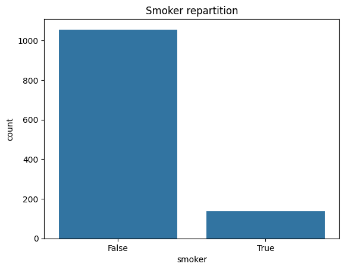

```python
sns.countplot(data=df_cost, x='smoker')
plt.title('Smoker repartition')
plt.show()
```

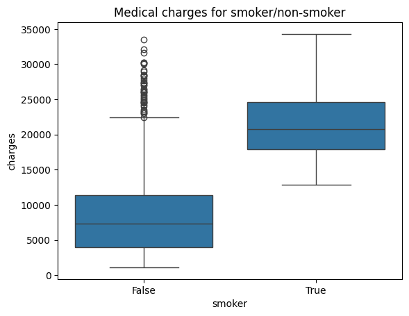

```python
sns.boxplot(data=df_cost, x='smoker', y='charges')
plt.title('Medical charges for smoker/non-smoker')
plt.show()
```

Most customers are non-smokers and we know that smoking is a key risk for health, so must be a key factor for medical expenses.

It is confirmed with the second graph, we have a very clear difference. We can however see that there is a large number of outliers for non-smoker, it could be interesting to understand what is the other factor for these people.

This confirms that smoking is a major cost driver in health insurance. Surcharge policies for smokers could help balance risk exposure. Encouraging preventive care for smokers may reduce long-term claim costs.

One more insight might be about the regional air pollution. We merged the two datasets in order to analyse its influence of insurance risks so let's compute some visualisation.

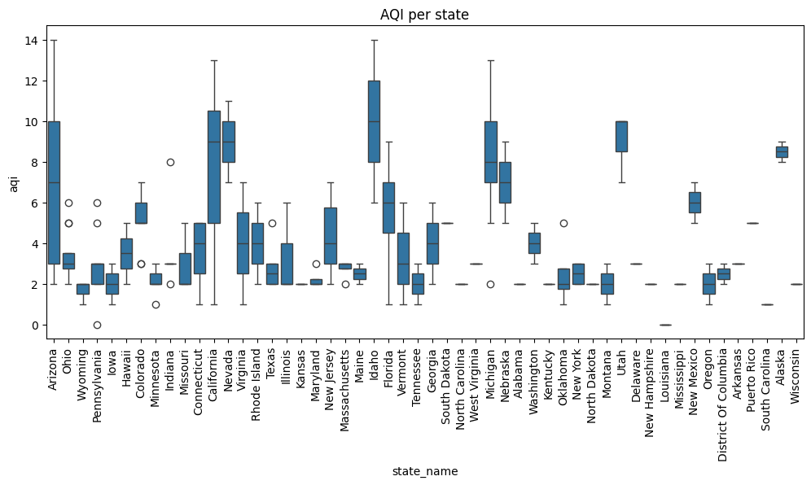

```python
plt.figure(figsize=(12,5))
sns.boxplot(data=df_air, x='state_name', y='aqi')
plt.xticks(rotation=90)
plt.title('AQI per state')
plt.show()
```

We can see large variations across states, some of them have really high pollution levels. This suggests that strong environmental factor are affecting the risks for health of these people, maybe on a longer term. In these specific regions, LifeSure could considerate changing its prices according to this dimension.

Customers from high-AQI states might face higher health risks due to pollution-related illnesses.

Key insights will be discovered thanks to the correlation matrix of our data. So let's compute the correlation matrix.

First of all, let's compute it for our first dataset, in order to focus on costs & insurance only, without taking into account the next dataset.

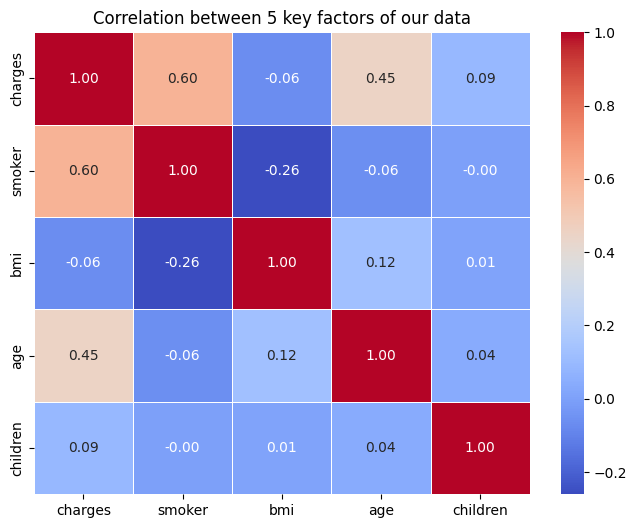

```python
cols = ["charges", "smoker", "bmi", "age", "children"]
corr_matrix = df_cost[cols].corr()

plt.figure(figsize=(8, 6))
sns.heatmap(corr_matrix, annot=True, cmap="coolwarm", fmt=".2f", linewidths=0.5)
plt.title("Correlation between 5 key factors of our data")
plt.show()
```

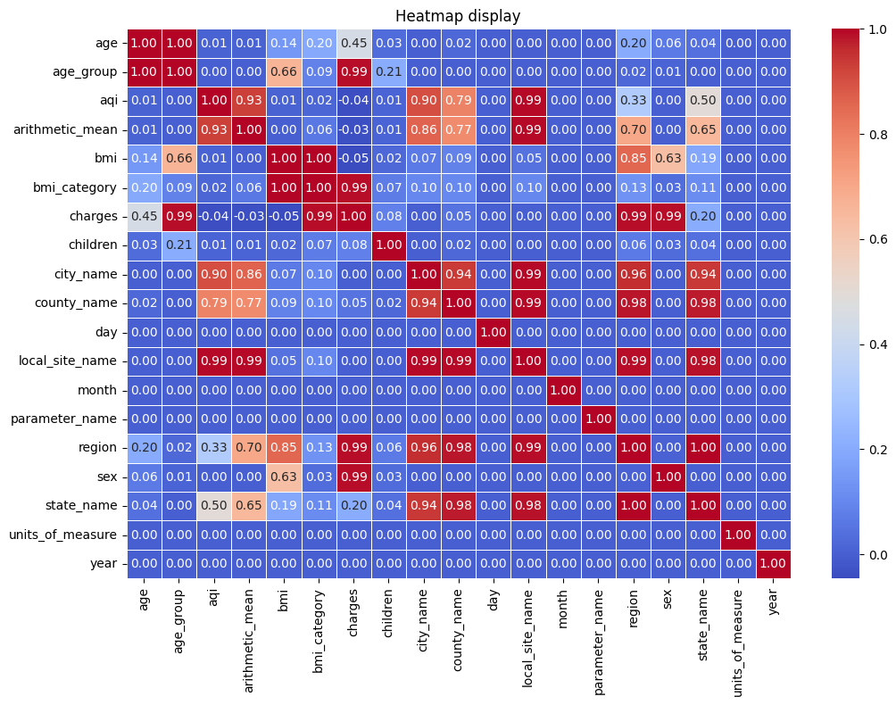

```python
import warnings

warnings.filterwarnings("ignore", category=RuntimeWarning) # just to ignore warning with division by 0

def cramers_v(x, y):
    confusion_matrix = pd.crosstab(x, y)

    if confusion_matrix.shape[0] < 2 or confusion_matrix.shape[1] < 2:
        return np.nan

    chi2 = chi2_contingency(confusion_matrix)[0]
    n = confusion_matrix.sum().sum()
    phi2 = chi2 / n
    r, k = confusion_matrix.shape
    phi2corr = max(0, phi2 - ((k-1)*(r-1)) / (n-1))
    r_corr = r - ((r-1)**2) / (n-1)
    k_corr = k - ((k-1)**2) / (n-1)

    denominator = min(r_corr-1, k_corr-1)
    if denominator <= 0:
        return np.nan

    return np.sqrt(phi2corr / denominator)

num_cols = df_merged.select_dtypes(include=['number']).columns
cat_cols = df_merged.select_dtypes(include=['category', 'object']).columns

corr_matrix = pd.DataFrame(index=num_cols.union(cat_cols), columns=num_cols.union(cat_cols))

for col1 in corr_matrix.columns:
    for col2 in corr_matrix.index:
        if col1 == col2:
            corr_matrix.loc[col1, col2] = 1
        elif col1 in num_cols and col2 in num_cols:
            corr_value = df_merged[col1].corr(df_merged[col2])
            corr_matrix.loc[col1, col2] = corr_value if not np.isnan(corr_value) else 0
        else:
            value = cramers_v(df_merged[col1].astype(str), df_merged[col2].astype(str))
            corr_matrix.loc[col1, col2] = value if not np.isnan(value) else 0

corr_matrix = corr_matrix.astype(float)

plt.figure(figsize=(12, 8))
sns.heatmap(corr_matrix, annot=True, cmap='coolwarm', fmt=".2f", linewidths=0.5)
plt.title("Heatmap display")
plt.show()
```

The strong correlation between smoker and charges confirms our analysis. The other factor we talked about in the analysis to explain why we had so many outliers might be the age, according to these correlations. We can obviously analyse weak correlations too, for example having more children does not strongly impact medical expenses.

## Identifying Key Insights

Now that we have some visualization, let's segment our customers based on factors important for LifeSure. We can, thanks to this analysis, advice LifeSure for its sustainability strategy.

According to our analysis, let's try to segment customers based on smoking status, age groups and BMI categories to try and offer LifeSure key insights for their policies.

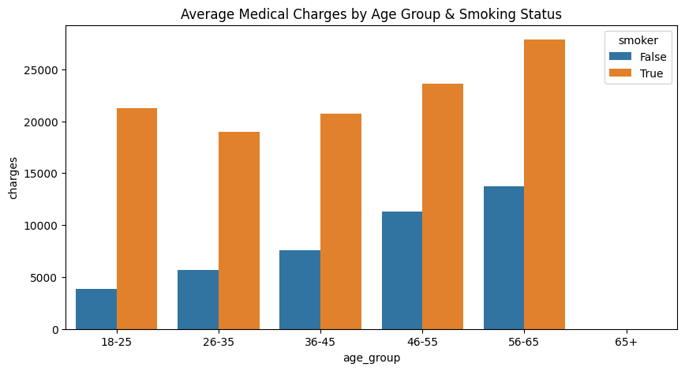

```python
customer_segments = df_cost.groupby(["smoker", "age_group"])["charges"].mean().reset_index()

plt.figure(figsize=(10,5))
sns.barplot(data=customer_segments, x="age_group", y="charges", hue="smoker")
plt.title("Average Medical Charges by Age Group & Smoking Status")
plt.show()
```

LifeSure could decide to encourage young people to remain non-smokers through discounts in their policies for example and introduce targeted smoking cessation programs to reduce long-term risks as this will lead to less charges at the end.

As we saw, we have strong variations in AQI depending on the region we're in. Let's see if this impacts insurance claims and medical charges.

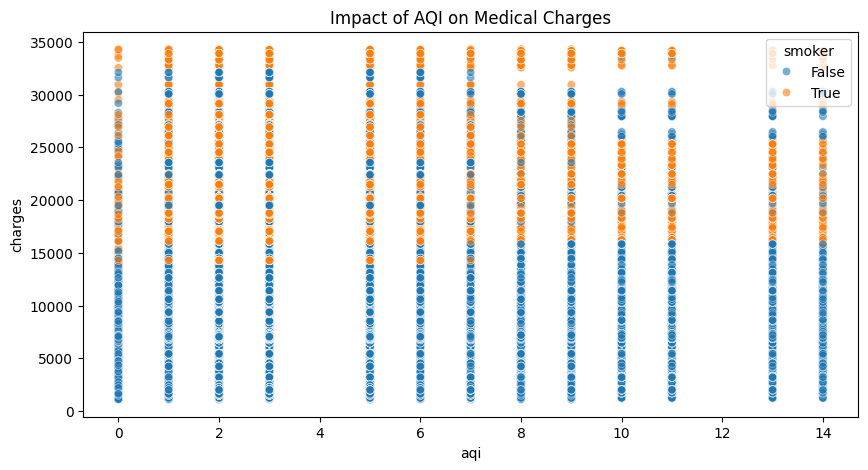

```python
plt.figure(figsize=(10,5))
sns.scatterplot(data=df_merged, x="aqi", y="charges", hue="smoker", alpha=0.6)
plt.title("Impact of AQI on Medical Charges")
plt.show()
```

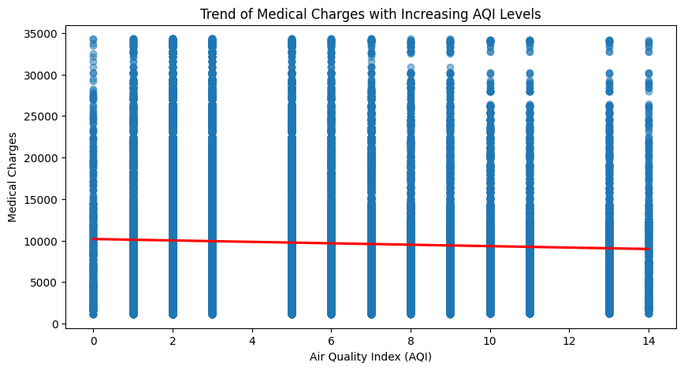

```python
plt.figure(figsize=(10, 5))
sns.regplot(data=df_merged, x="aqi", y="charges", scatter_kws={'alpha': 0.5}, line_kws={"color": "red"})
plt.title("Trend of Medical Charges with Increasing AQI Levels")
plt.xlabel("Air Quality Index (AQI)")
plt.ylabel("Medical Charges")
plt.show()
```

This confirms our analysis. We can see that charges have no strong relation with AQI. This does not mean that this is not important, as AQI is very low here (AQI below 20 is considered excellent !) and we don't have data for high level of pollution. Furthermore, pollution could lead to later cardiovascular diseases, and the impact is not visible on the actual data. So this could be considerated by LifeSure even if the correlation is not strong yet. Other factors (e.g., smoking, age, BMI) likely have a stronger influence on costs.

Let's go a little further and segment our customers based on these factors using K-Means clustering.

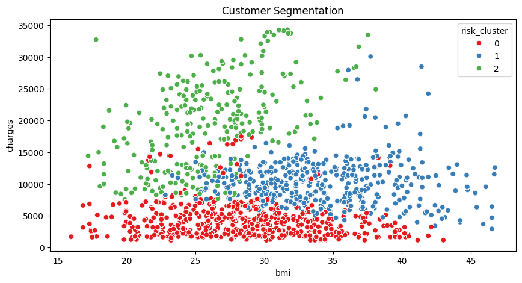

```python
X = df_merged[['age', 'bmi', 'charges', 'aqi']]
X_scaled = StandardScaler().fit_transform(X)

kmeans = KMeans(n_clusters=3, random_state=42)
df_merged['risk_cluster'] = kmeans.fit_predict(X_scaled)

plt.figure(figsize=(10,5))
sns.scatterplot(data=df_merged, x='bmi', y='charges', hue='risk_cluster', palette='Set1')
plt.title('Customer Segmentation')
plt.show()
```

## Specifications Document

Next to this notebook is linked a specifications document that define the goals of our project and the key metrics we used. It provides recommendations for LifeSure, and for the implementation of the interface.

# Phase 3 : Visualization and Communication of Results

Now that we understand more deeply our dataset, and the key factors, let's create some visualization in a simple format for LifeSure's decision-makers.

[figure not shown]

The dashboard is attached to this file and is available to be run. Here are some illustration pictures

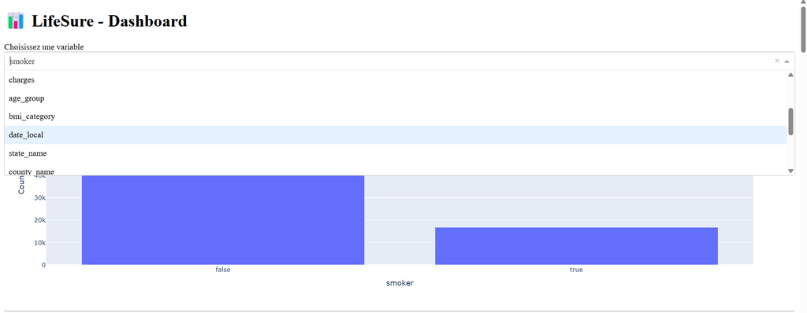

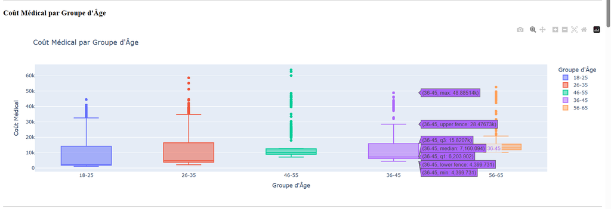

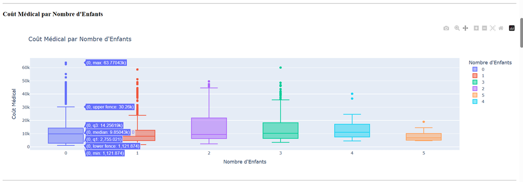

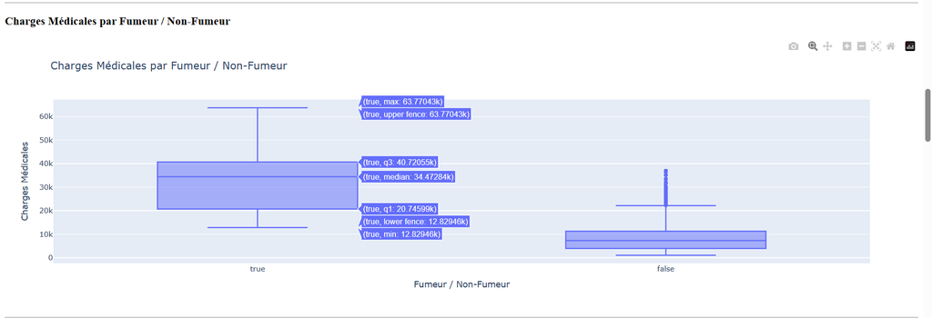

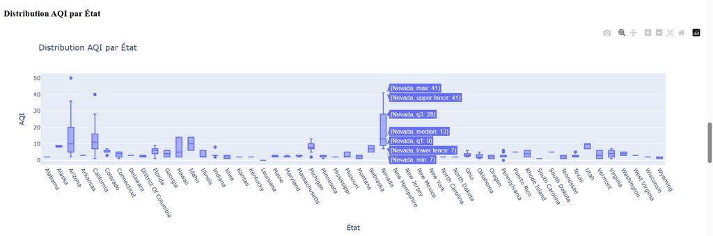

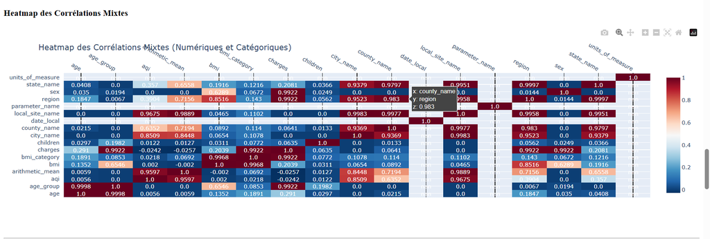

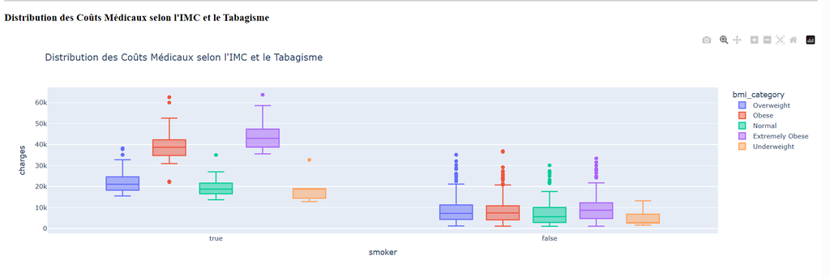

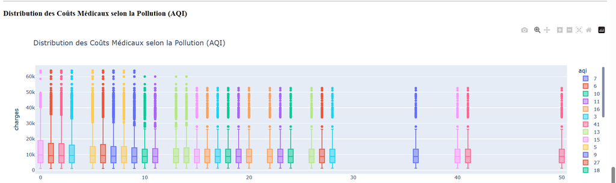

These visualisations are interactive visualisations that are representative of the analysis in this notebook. This will help LifeSure take data-driven decisions.

```python
from google.colab import drive
drive.mount('/content/gdrive')
#%%shell
!jupyter nbconvert --to html '/content/gdrive/MyDrive/Colab Notebooks/GINDRE_Louis_DIA1_Lab2_TODO_Deep_Computer_Vision.ipynb'
```